# Draft ADF&G Biometrics Best Practices

Ben Williams

2017-07-05

This document is to explicitly list coding best practices in *R* for biometricians and quantitative biologists within ADF&G Commercial Fisheries, with the hopes that a common framework will facilitate collaboration and code review. Much of what is in here originates from Grolemund and Wickham’s excellent R for Data Science “Book” http://r4ds.had.co.nz/. This is all predicated upon the assumption that your data are human and machine readable!

## Naming conventions

Generally speaking it is best to use Google’s R style guide, if in doubt default to these: https://google.github.io/styleguide/Rguide.xml

**File names** Do use:  
`lower_case_and_underscore.R`

If you are changing files or versions often then adding a date can be beneficial.  
`data_2017_01_20.csv`  
or add a version  
`data_2017_01_20_v2.csv`

Do not use:  
`DontUseMixedCases.R`  
`periods.are.meh.but.ok.csv`  
`dont_use.periods_and.underscore.R`

Definitely don’t use a name that only you can understand  
`X10_20.16_T_AND_Y410.csv`

Be consistent within and across projects. For example, all data file names contain the same information:  
`datasource_briefdescription_firstyear_lastyear.csv`  
Examples:  
`survey_bio_1988_2016.csv` or  
`fishery_cpue_1998_2016.csv`

**Object names**

Rename all columns on import of a dataset. Do this at the beginning of a script to make sure that files can be joined without naming conflicts.

Keep names short, but descriptive.

Use:  
`year` or `Year`  
`cpue` or `std.cpue` (update: I’ve moved away from using `.` and now use `_` e.g., std_cpue)

`No spaces`  
`No_Upper_And_Upper_Case`  
`NO_ALL_CAPS`

`catch` works better than `c` and you can search for and change `catch` (plus `c` is a function command…)

Know your data types, if an object is a character or factor use a capital letter, if it is numeric (double, or integer) use a lower case name. Define data types at the beginning of a script.

For example you have the integer `year` in your data but you create figures based on the factor `Year`. If you keep the two seperate you have the ability to easily plot and run various analyses without getting errors plus:

`lm(catch~year)` is quite a bit different than `lm(catch~Year)`

Instead of writing `catch_kg` make a note at the beginning of the script that catch is in kg unless otherwise stated then use `catch`. Making notes in your code files is just good practice in general.

**Dates**  
Believe it or not there is an international date/time standard (ISO 8601) the format is:  
yyyy-mm-dd

*Use it!* Dates regularly have confounding errors - clean them at the beginning of a script and make all formats consistent (because what people send you will not be).

**Function names**

I often start function names with an *f* at the beginning, to clearly identify them as a function.

`f_brief_function_description`

Something like `f_ricker` or `ricker_fun` to name a Ricker spawner-recruit function. Functions named *r*, *rick*, or *sr* don’t tell you what it does - be at least slightly descriptive.

**Assignments**  
Use `<-`, not =  
Use TRUE and FALSE, not T or F (the latter can be reassigned, the former cannot).

The `<-` assignment shortcut is `Alt-`, the “pipe” `%>%` operator shortcut is `Cntrl+Shift+M` more shortcuts in Rstudio can be found by pressing `Alt+Shift+K`.

**Spacing**

Place spaces around all binary operators (=, +, -, `<-`, etc.). Do not place a space before a comma, but always place one after a comma. Place a space before left parenthesis, except in a function call. There should be a hard return after each pipe `%>%`.

# Organization

## Projects

*Use them!*  
Don’t save your work environment - you should rerun your code each time to make sure you haven’t broken anything. If the analyses are lengthy or complex then save the output - which can then be sourced. In Rstudio you can go to “Tools > Global Options> Save workspace to .Rdata on exit” change it to “Never” and your workspace will not be saved.  
**Don’t use absolute paths** no `set_wd()` or `attach` in your scripts - if data are confidential then write a note in the script of how to call the data (e.g., OceanAK), or where it is stored on a ADF&G server, or whom to contact. Why does this matter? Your `set_wd()` is not the same as mine. Relative paths only - hence the reason for projects. **Only load packages that you are actually using.**

### Project structure

If everyone uses a similar structure for projects and scripts we will be able to read and understand each other’s work faster and more easily.  
A project should have a number of folders:

- code - all scripts (use separate folders for r-code, admb, etc.)
- data - raw data - this gets treated as a read only file, never adjust the contents of this file - everything is done via code
- figs - this is .png etc., output
- text - if writing a document it is easier to keep it seperate

sometimes there may be inclusion of a few other folders, such as:

- output - any cleaned data
- literature

This structure works well for developing R scripts, writing in markdown and can work well when writing with Sweave.

## Scripts

The general structure of a script should have:

- A decription of what it does
- Who made it and their contact e-mail
- Further notes on data access, units, etc.
- list all libraries used in the analysis - have libraries you no longer use? **delete them** it will reduce conflicts.
- typically I bring in all data at the start and clean it. If the files are huge, or numerous, there may be a code chunk(s) deeper into the script to deal with it.
- fold your code!  
  Use `# load ----` or `# data ----` to create breaks and make it easy to navigate within your scripts and make lengthy analyses much easier to follow.

At a minimum a script structure should look like:

`# notes ----`

`# author`  
`# contact`  
`# date (or last changed date)`

`# load ----`

`library()`  
`source('code/functions.R')`

`# data ----`  
`data <- read_csv('data/data_file.csv')`

```
data %>%
    mutate(Year = factor(year)) -> data
```

`# analysis ----`

For example:

```r
# notes ----
# This is a demonstration of how scripts should be setup
# Author: Ben Williams
# contact: ben.williams@alaska.gov
# Last edited: 2017-7-7

# load ----
library(tidyverse)
library(FNGr)
theme_set(theme_sleek())

# data ----
# typically this would be read_csv("data/iris.csv")
# but the iris dataset is built in

# change names
names(iris) <- c('sepal_length', 'sepal_width', 'petal_length', 'petal_width', 'Species')
glimpse(iris)
```

```
## Observations: 150
## Variables: 5
## $ sepal_length <dbl> 5.1, 4.9, 4.7, 4.6, 5.0, 5.4, 4.6, 5.0, 4.4, 4.9,...
## $ sepal_width  <dbl> 3.5, 3.0, 3.2, 3.1, 3.6, 3.9, 3.4, 3.4, 2.9, 3.1,...
## $ petal_length <dbl> 1.4, 1.4, 1.3, 1.5, 1.4, 1.7, 1.4, 1.5, 1.4, 1.5,...
## $ petal_width  <dbl> 0.2, 0.2, 0.2, 0.2, 0.2, 0.4, 0.3, 0.2, 0.2, 0.1,...
## $ Species      <fct> setosa, setosa, setosa, setosa, setosa, setosa, s...
```

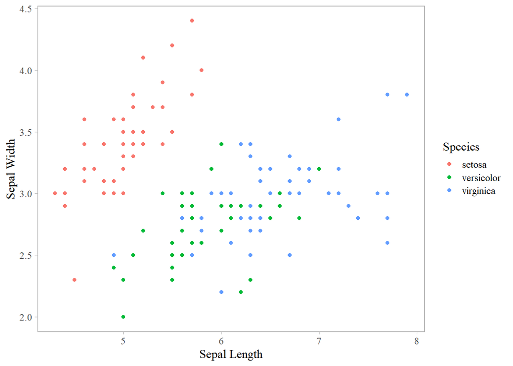

```r
# eda ----

ggplot(iris, aes(sepal_length, sepal_width, color=Species)) +
  geom_point() +
    ylab('Sepal Width') +
  xlab('Sepal Length')
```

## Rmarkdown

*Note: This section is under development*

What is markdown?

- a very lightweight writing format originally created for conversion to HTML (a “markup” language - that is a pain to write)
- it is plain text (no proprietary software - looking at you MS Word) so can be tracked via git
- what can it be converted to?  
  pdf, word, html
- How does that work? via a program called Pandoc (a “universal” document converter) - don’t worry it is included with RStudio.

When to use it

-Whenever you want to rapidly communicate annotated code (informal report) -Initial report writing  
-To keep notes for yourself

Structure  
* YAML - ‘YAML Ain’t Markup Language’ a human (and computer) readable data format. This is the “frontmatter” of your report that tells markdown what type of output you would like to have.  
* there are a slew of options http://rmarkdown.rstudio.com/html_document_format.html - I’ve generally found that keeping it rather basic e.g.,

```r
---
title: 'This is a title'
author: 'Me'
date: "2017_06_10"
output:pdf_document
fontsize: 11pt
csl: canjfas.csl
bibliography: bibby.bib
---
```

This has a title, author and date that will be at the head of the document. I’ve told it to generate a pdf and have included a bibliography (.bibtex format) for references and am using the Canadian Journal or Fisheries and Aquatic Sciences .csl (citation style language) that format the references. Here is a good site for downloading .csl styles https://github.com/citation-style-language/styles